# Data Preprocessing

### **Rating Attribute**

```python
new_data.info()
```

```
<class 'pandas.core.frame.DataFrame'>
Index: 10358 entries, 0 to 10840
Data columns (total 22 columns):
 #   Column                Non-Null Count  Dtype
---  ------                --------------  -----
 0   App                   10358 non-null  object
 1   Category              10358 non-null  object
 2   Rating                10358 non-null  float64
 3   Reviews               10358 non-null  int32
 4   Size                  10358 non-null  float64
 5   Installs              10358 non-null  int32
 6   Type                  10358 non-null  object
 7   Price                 10358 non-null  float64
 8   Content Rating        10358 non-null  object
 9   Genres                10358 non-null  object
 10  Last Updated          10358 non-null  datetime64[ns]
 11  Current Ver           10358 non-null  object
 12  Android Ver           10358 non-null  object
 13  Reviews Category      9765 non-null   category
 14  Size Category         10358 non-null  category
 15  Installs Categorical  10358 non-null  category
 16  Price Category        10358 non-null  category
 17  Rating Category       10358 non-null  category
 18  Last Updated Day      10358 non-null  int32
 19  Last Updated Month    10358 non-null  object
 20  Last Updated Year     10358 non-null  int32
 21  Minimum Android Ver   10358 non-null  object
dtypes: category(5), datetime64[ns](1), float64(3), int32(4), object(9)
memory usage: 1.3+ MB
```

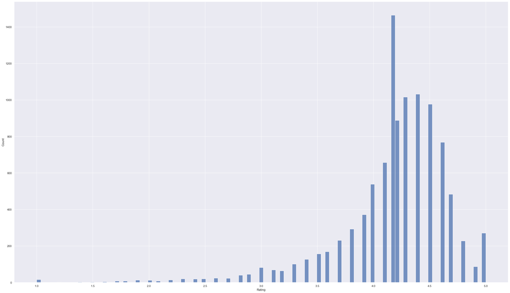

```python
sns.histplot(data=new_data,x='Rating')
```

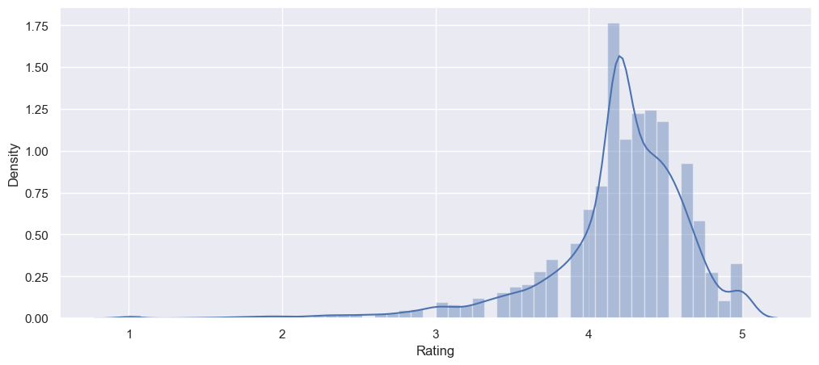

```python
plt.figure(figsize=(12,5))
sns.distplot(new_data['Rating'])
```

```python
new_data['Rating'].skew()
```

```
-1.9736671250371018
```

- This suggests that there are relatively more ratings towards the higher end of the scale, with fewer ratings towards the lower end.
- The skewness value being significantly negative indicates a pronounced left skew, indicating a heavier concentration of ratings towards the higher end of the scale.

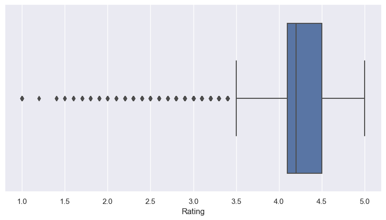

```python
plt.figure(figsize=(10, 5))
ax = sns.boxplot(data=new_data, x='Rating')

plt.show()
```

In simpler terms, this tells us that most ratings are clustered between 3.5 and 5.0, with some very low ratings considered as outliers. The typical (median) rating is 4.2, and the average (mean) rating is slightly lower at 4.18.